# Final Project

Bailey Vande Griend

4/28/2020

How has Baseball Changed Recently?

It’s no secret that baseball’s popularity has been in question recently. Some say its a dying sport, while others insist it is only stagnant and still has room to grow. Regardless, many efforts have been made to make baseball more exciting to watch. One such change involved changing the league standard for the baseball. This was done in 2017, and more recently in 2019. The question is, has this actually affected the sport? To answer this question, we will be looking at hitting stats from the last 4 years to see if there are any differences.

```r
##Creating and cleaning our data
setwd("/Users/baile/OneDrive/Git/Stat-344")
library(readxl)
Bball2016 <- read_excel("2016Stats.xlsx")
Bball2016$Year <- 2016
Bball2017 <- read_excel("2017Stats.xlsx")
Bball2017$Year <- 2017
Bball2018 <- read_excel("2018Stats.xlsx")
Bball2018$Year <- 2018
Bball2019 <- read_excel("2019Stats.xlsx")
Bball2019$Year <- 2019
Bball2019 <- Bball2019[-c(32,33),]
baseball <- rbind(Bball2016, Bball2017, Bball2018, Bball2019)
baseball <- baseball[-c(2:3,15,24:29)]
for (i in 2:20){
  baseball[[i]] <- as.numeric(unlist(baseball[[i]]))
}
baseball$shYear <- as.factor(c(rep(16,31),rep(17,31),rep(18,31),rep(19,31)))
```

Analyzing Home Runs

Since the home run is the most exciting play in baseball (after all, chicks do dig the long ball), we will begin by analyzing how home runs have been affected by the change in the baseball. First we will look at a simple barplot to see the differences in the years.

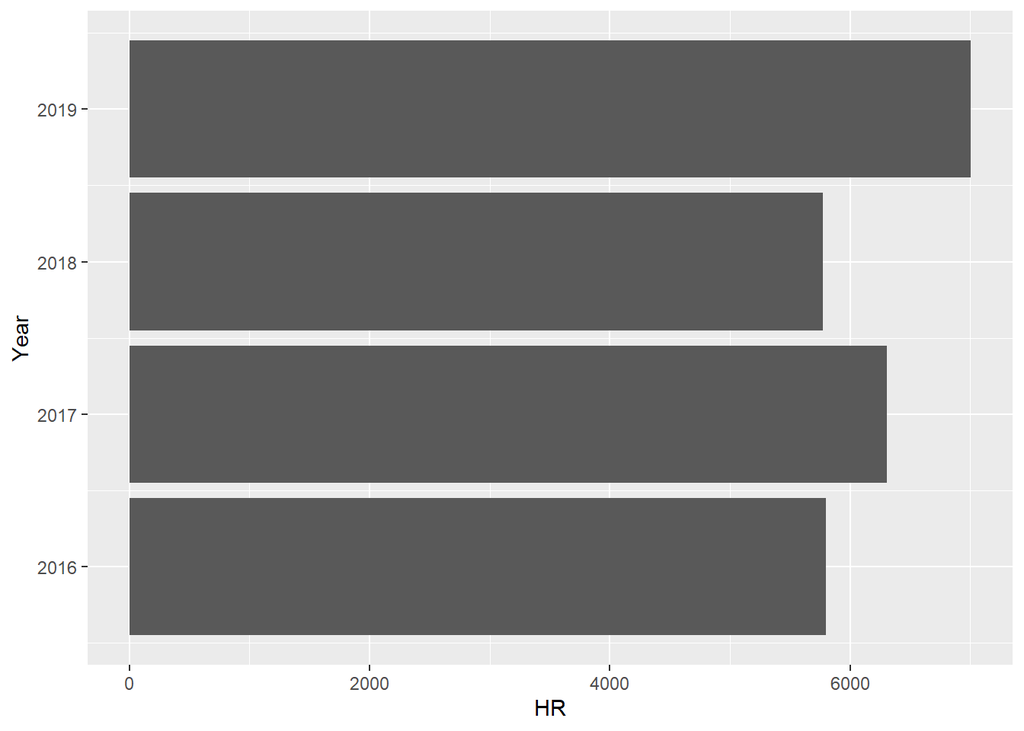

```r
library(ggplot2)
HRs <- aggregate(HR ~ Year, baseball, sum)
ggplot(HRs,aes(x = Year, y = HR)) + geom_bar(stat = "identity") + coord_flip()
```

Lets look at it differently, to see progression over time easier

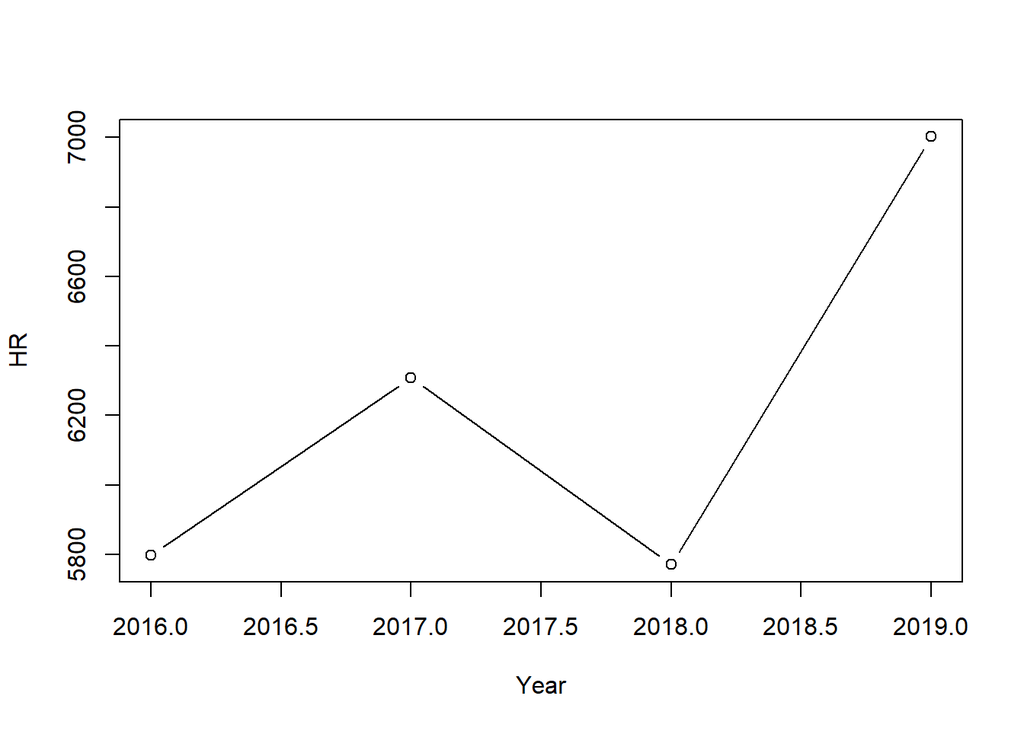

```r
plot(HR ~ Year, data = HRs, type = "b")
```

This is only the data for the total home runs per year, what if we include each team’s amount of homeruns per year?

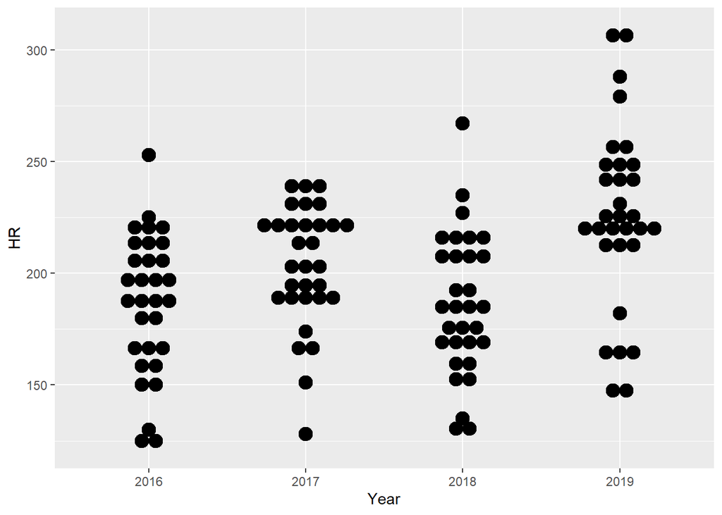

```r
baseball[[21]] <- as.factor(baseball[[21]])
ggplot(baseball, aes(x=Year, y=HR)) +
  geom_dotplot(binaxis='y', stackdir='center')
```

It might be easier to see differences using a boxplot

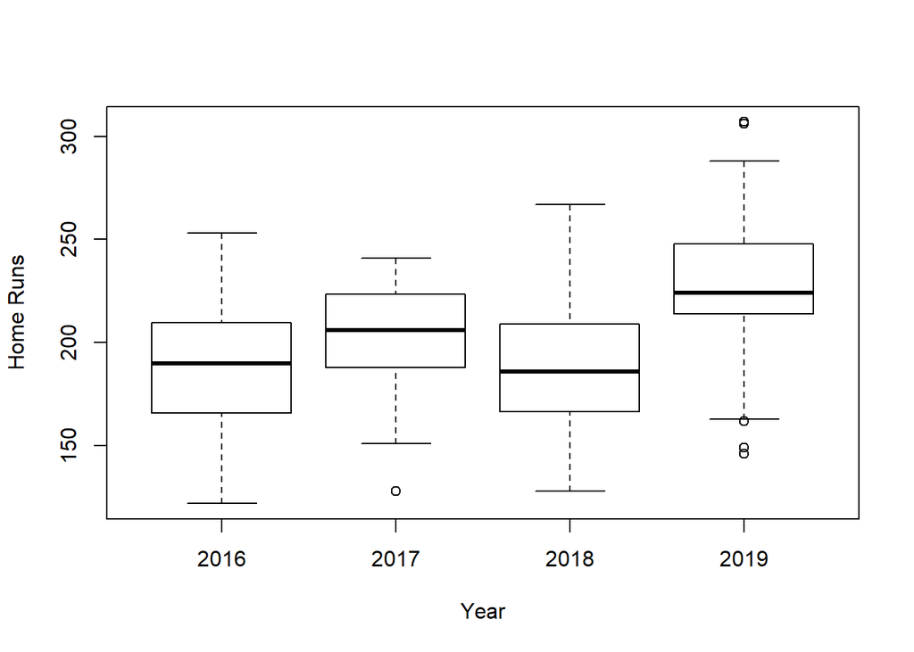

```r
boxplot(baseball$HR ~baseball$Year, ylab = "Home Runs", xlab = "Year")
```

To see each team specifically

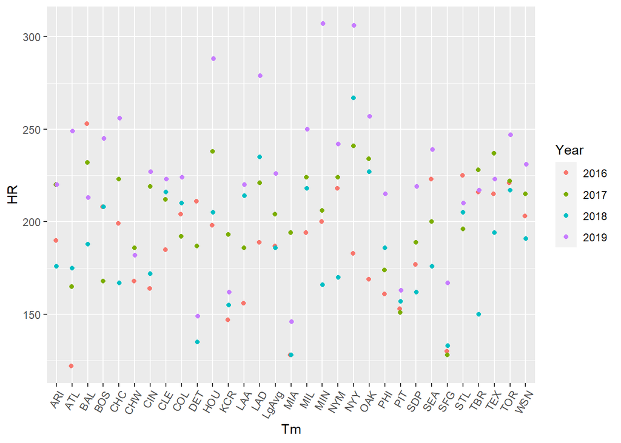

```r
ggplot(data=baseball, aes(x=Tm, y=HR, color=Year)) +
  geom_point(position=position_dodge(width=.1)) + theme(axis.text.x = element_text(angle = 60, hjust = 1))
```

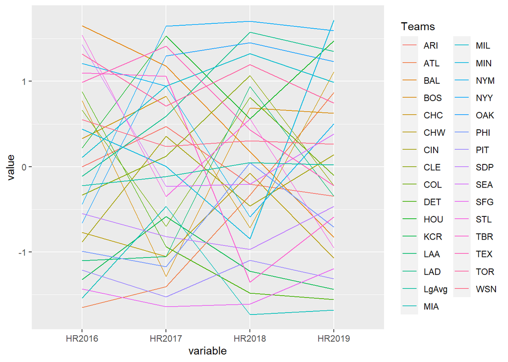

```r
HR2016 <- as.numeric(baseball$HR[baseball$Year == 2016])
HR2017 <- as.numeric(baseball$HR[baseball$Year == 2017])
HR2018 <- as.numeric(baseball$HR[baseball$Year == 2018])
HR2019 <- as.numeric(baseball$HR[baseball$Year == 2019])
Teams <- baseball$Tm[baseball$Year == 2016]
HRFrame <- cbind(HR2016, HR2017, HR2018, HR2019, Teams)
library(GGally)
ggparcoord(HRFrame, columns = 1:4, groupColumn = 5)
```

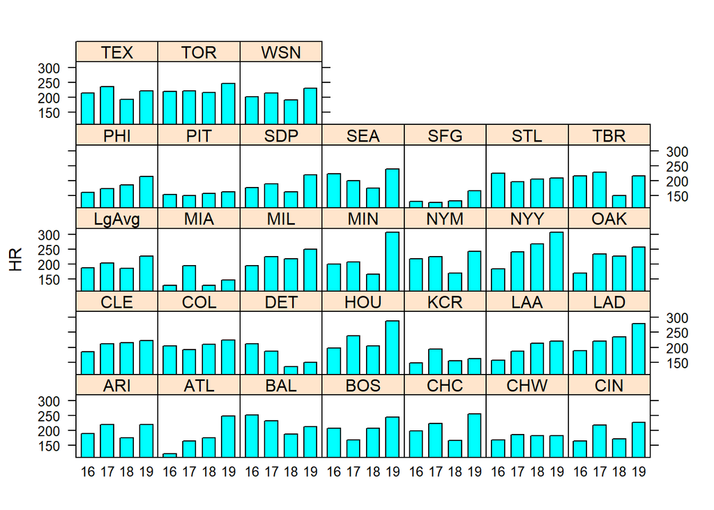

```r
library(lattice)
yrvec = c(2016,2017,2018,2019)
barchart(HR ~ shYear | Tm, baseball)
```

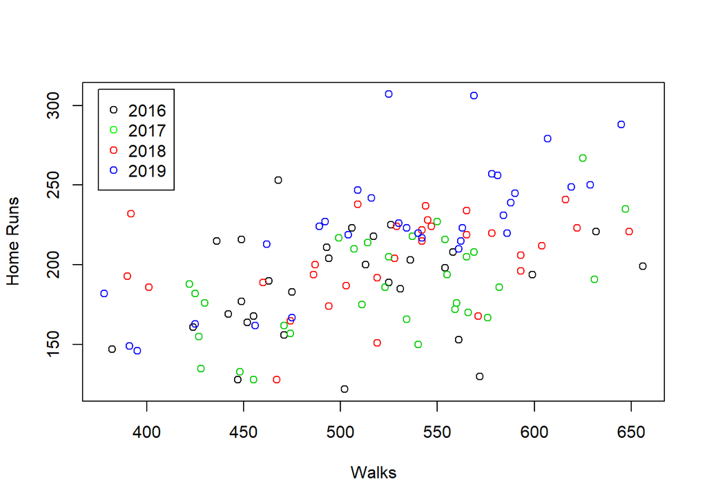

```r
baseball[[21]] <- as.numeric(baseball[[21]])
HRModel <- lm(baseball$HR ~ baseball$BB + baseball$Year, data = baseball)
plot(baseball$HR ~ baseball$BB, xlab = "Walks", ylab = "Home Runs",  col=as.integer(baseball$Year))
legend(375, 310, legend = c("2016", "2017", "2018","2019"), pch=1, col=c("Black", "Green", "Red", "Blue"))
```

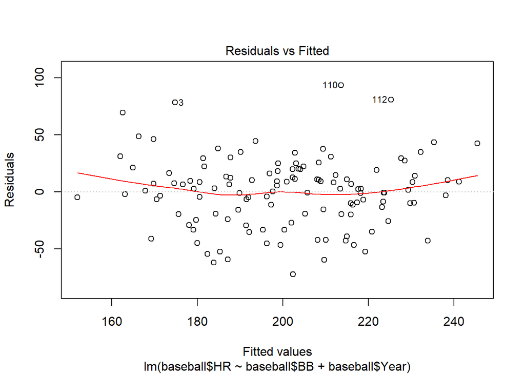

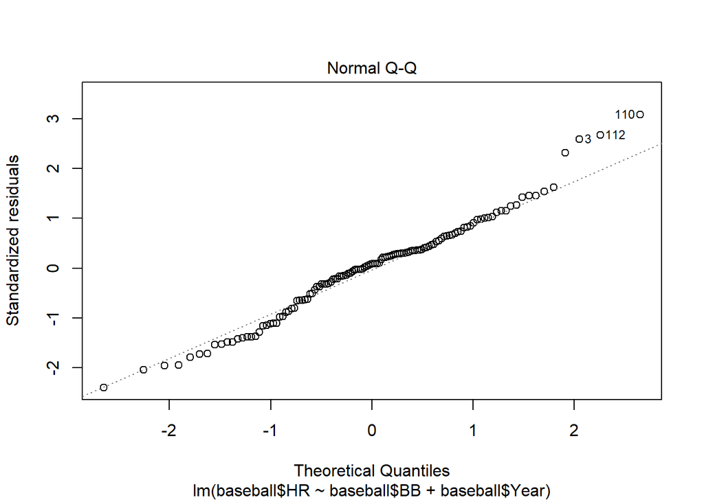

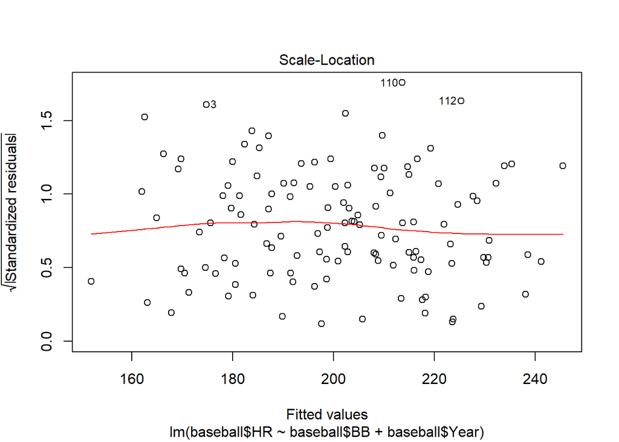

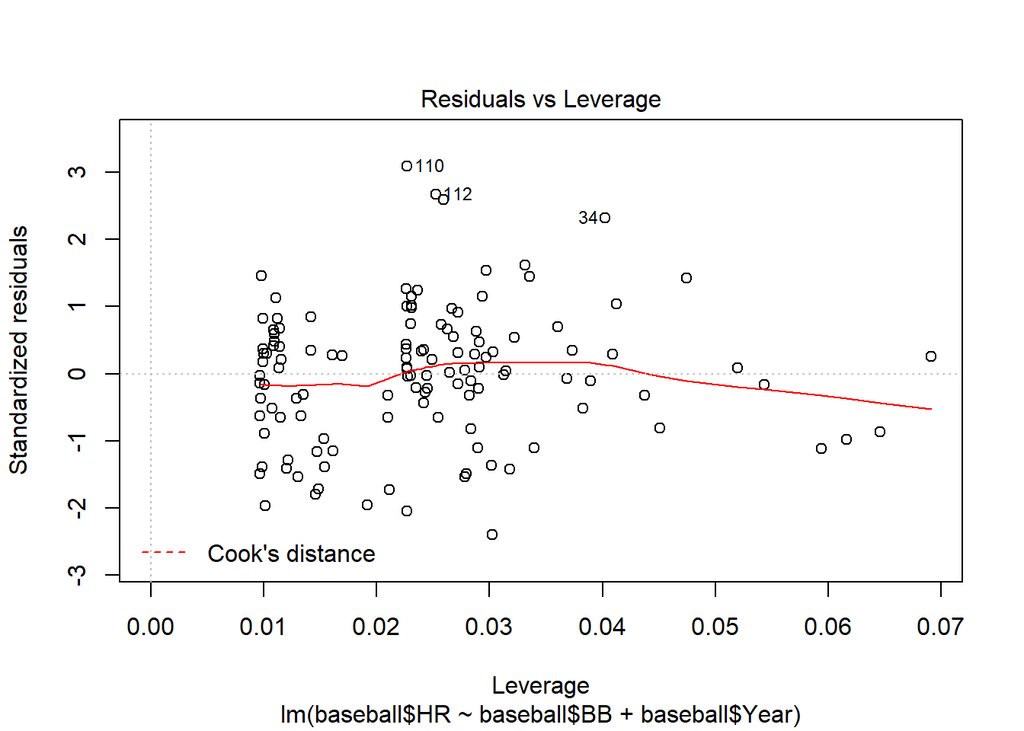

```r
plot(HRModel)
```

```r
summary(HRModel)
```

```
##
## Call:
## lm(formula = baseball$HR ~ baseball$BB + baseball$Year, data = baseball)
##
## Residuals:
##     Min      1Q  Median      3Q     Max
## -72.355 -19.328   2.505  16.982  93.389
##
## Coefficients:
##               Estimate Std. Error t value Pr(>|t|)
## (Intercept)   42.62448   22.51837   1.893  0.06076 .
## baseball$BB    0.26542    0.04282   6.199 8.17e-09 ***
## baseball$Year  7.91033    2.48011   3.190  0.00181 **
## ---
## Signif. codes:  0 '***' 0.001 '**' 0.01 '*' 0.05 '.' 0.1 ' ' 1
##
## Residual standard error: 30.61 on 121 degrees of freedom
## Multiple R-squared:  0.3114, Adjusted R-squared:    0.3
## F-statistic: 27.36 on 2 and 121 DF,  p-value: 1.573e-10
```

```r
anova(HRModel)
```

```
## Analysis of Variance Table
##
## Response: baseball$HR
##                Df Sum Sq Mean Sq F value    Pr(>F)
## baseball$BB     1  41742   41742  44.548 7.928e-10 ***
## baseball$Year   1   9532    9532  10.173  0.001815 **
## Residuals     121 113378     937
## ---
## Signif. codes:  0 '***' 0.001 '**' 0.01 '*' 0.05 '.' 0.1 ' ' 1
```

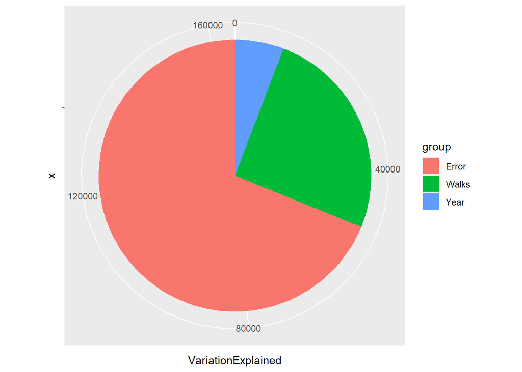

```r
baseball[[21]] <- as.factor(baseball[[21]])
HRchart <-data.frame(
  group = c("Walks","Year","Error"),
  value = c(41742,9532,113378)
)
HRchart$VariationExplained <- HRchart$value
ggplot(HRchart, aes(x="", y=VariationExplained, fill=group))+
geom_bar(width = 1, stat = "identity") + coord_polar("y", start=0)
```

First we need to check our assumptions to see if our linear model is appropriate. Since the relationship appears linear, The variance of the residuals seems even, the QQ normal plot seems linear, and the observations are independent, the assumptions are met and we can continue with our linear model.

The linear model using year and walks to predict home runs is

Home runs = 42.62 + 0.2654(walks) + 7.91033(year). The total amount of variation explained in home runs is about 31%, with walks explaining 25% and year explaining 6%. The biggest takeaway here seems to be that walks does seem to have an effect on the amount of homeruns hit.

It seems pretty clear that home runs increased in 2019, but what else changed? Let’s look at a heatmap of all teams and their hitting statistics to see

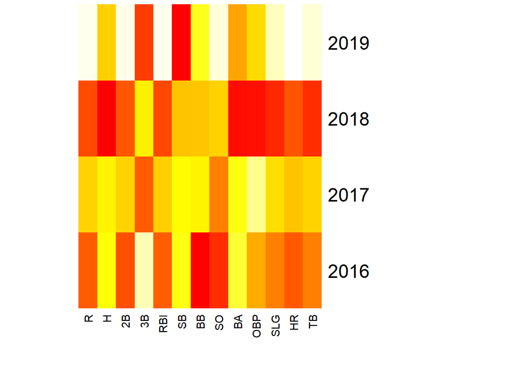

```r
Runs <- aggregate(R ~ Year, baseball, sum)
Hits <- aggregate(H ~ Year, baseball, sum)
Doubles <- aggregate(baseball$`2B` ~ Year, baseball, sum)
Triples <- aggregate(baseball$`3B` ~ Year, baseball, sum)
RBI <- aggregate(RBI ~ Year, baseball, sum)
SB <- aggregate(SB ~ Year, baseball, sum)
Walks <- aggregate(BB ~ Year, baseball, sum)
SO <- aggregate(SO ~ Year, baseball, sum)
Average <- aggregate(BA ~ Year, baseball, sum)
OBP <- aggregate(OBP ~ Year, baseball, sum)
Slg <- aggregate(SLG ~ Year, baseball, sum)
Bases <- aggregate(TB ~ Year, baseball, sum)
baseballMatrix <- cbind(Runs[2], Hits[2], Doubles[2], Triples[2], RBI[2], SB[2], Walks[2], SO[2], Average[2], OBP[2], Slg[2], HRs[2], Bases)
baseballMatrix$Year <- as.factor(baseballMatrix$Year)
row.names(baseballMatrix) <- c(2016,2017,2018,2019)
baseballMatrix <- baseballMatrix[-13]
colnames(baseballMatrix)[3] <- "2B"
colnames(baseballMatrix)[4] <- "3B"
baseballMatrix <- as.matrix(baseballMatrix)
heatmap(baseballMatrix, Rowv=NA, Colv=NA, col = heat.colors(256), scale="column", margins=c(5,10))
```

Many interesting things stand out here. As expected, 2019 is highest in total bases, slugging, RBIs, and runs.For many baseball fans, these are all good things that increase excitement. However, it is also highest in strikeouts, and it isn’t the highest in batting average or on base percentage. Strikeouts are arguably the least exciting thing in baseball. Did changing the ball increase the amount of strikeouts as well as home runs? We are going to look closer to see if there is a connection between homeruns hit in a season and strikeouts to see.

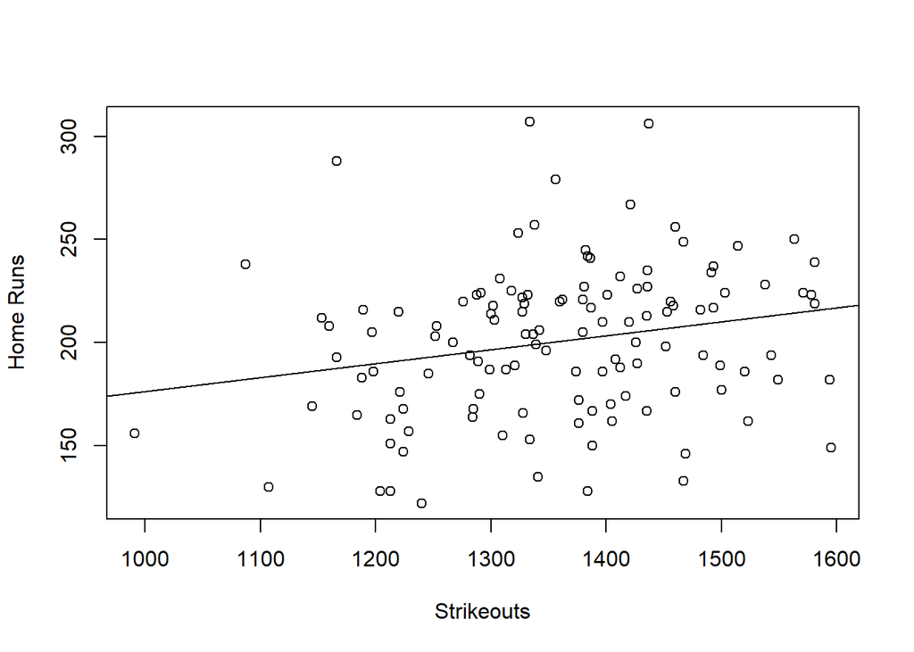

```r
plot(baseball$HR ~ baseball$SO, xlab = "Strikeouts", ylab = "Home Runs")
reg<-lm(HR ~ SO, data = baseball)
abline(reg, col="black")
```

There isn’t super strong correlation here, lets include year to see if anything stands out

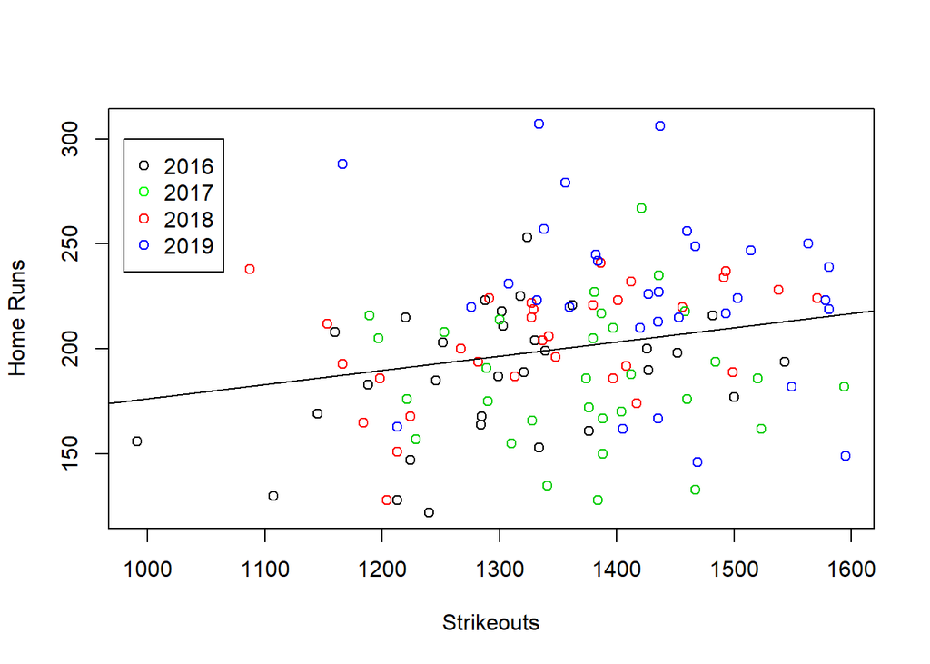

```r
plot(baseball$HR ~ baseball$SO, xlab = "Strikeouts", ylab = "Home Runs",  col=as.integer(baseball$Year))
abline(reg, col="black")
legend(980, 300, legend = c("2016", "2017", "2018","2019"), pch=1, col=c("Black", "Green", "Red", "Blue"))
```

Looking at the graph now with year included, we see that most of the extreme values happened in 2019. 2019 seems to be the year with significantly more strikeouts, as well as more Home Runs. Lets look closer into strikeouts per year.

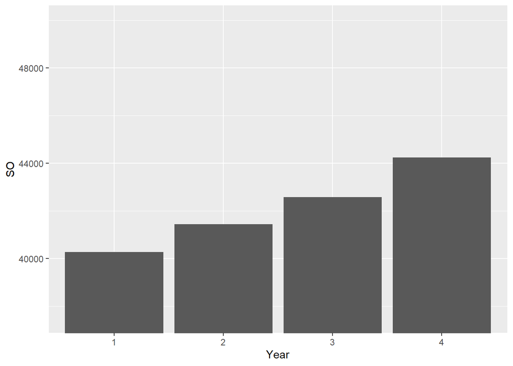

```r
ggplot(SO,aes(x = Year, y = SO)) + geom_bar(stat = "identity") + coord_cartesian(ylim = c(37500, 50000))
```

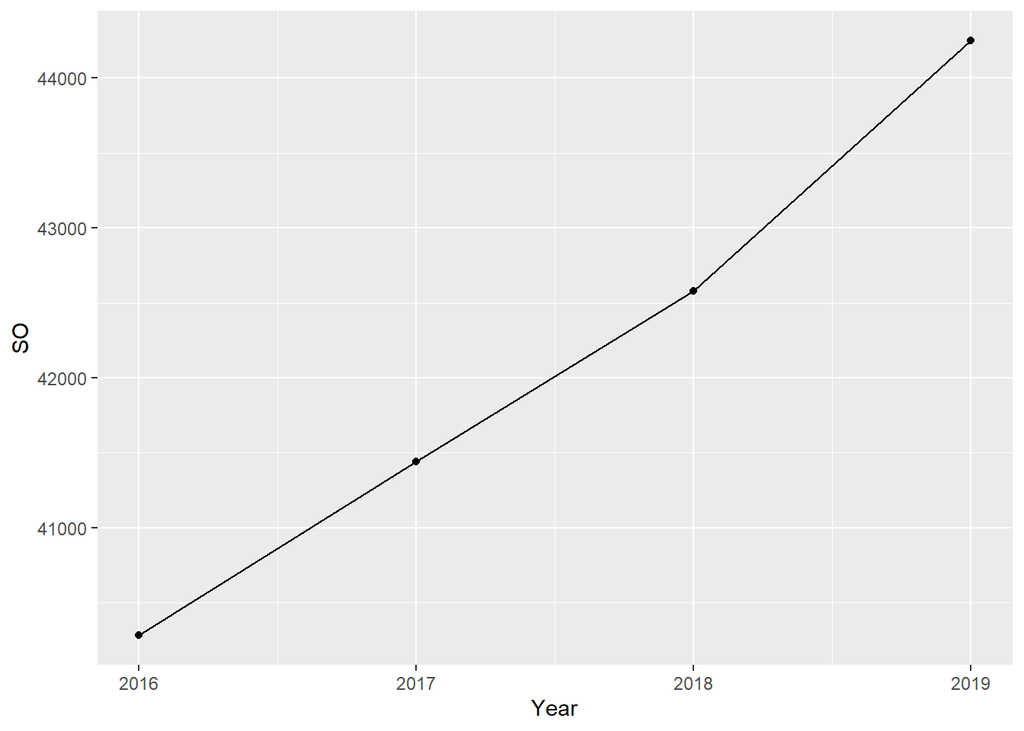

```r
SO$Year <- c(2016,2017,2018,2019)
ggplot(SO,aes(x = Year, y = SO)) + geom_point() + geom_line()
```

These graphs show a clear increase in strikeouts in 2019, however it also appears that the increase may be part of a natural increase in strikeouts over the past 4 years, as it follows the trend line. Lets look at each teams strikeout totals over the last four years to see more

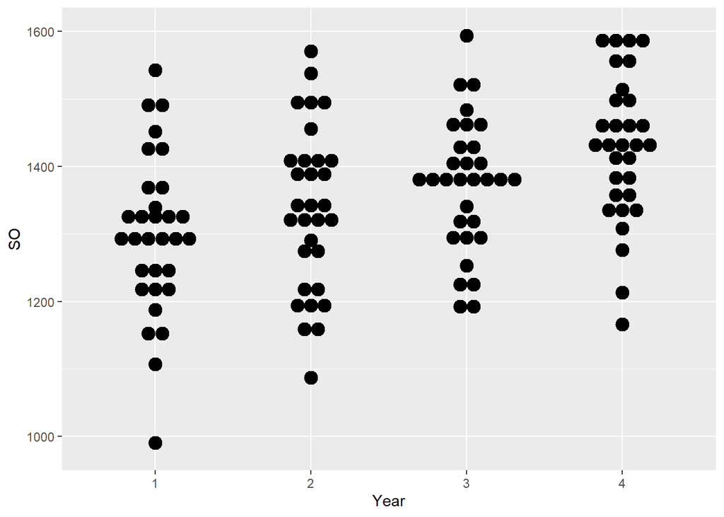

```r
ggplot(baseball, aes(x=Year, y=SO)) +
  geom_dotplot(binaxis='y', stackdir='center')
```

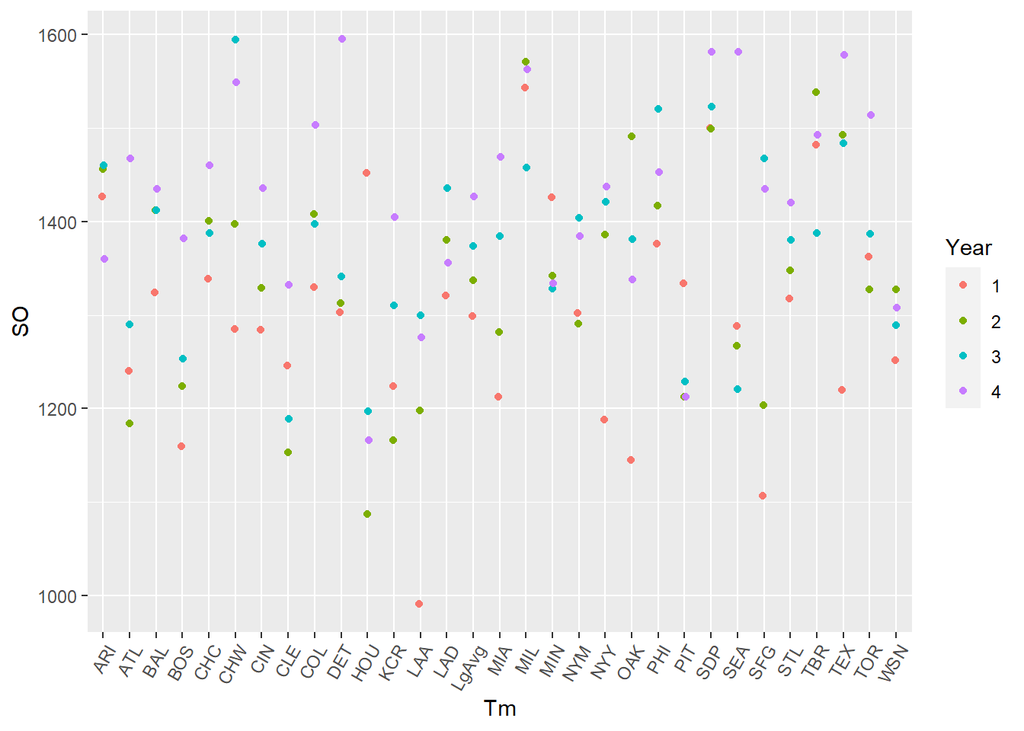

```r
ggplot(data=baseball, aes(x=Tm, y=SO, color=Year)) +
  geom_point(position=position_dodge(width=.1)) + theme(axis.text.x = element_text(angle = 60, hjust = 1))
```

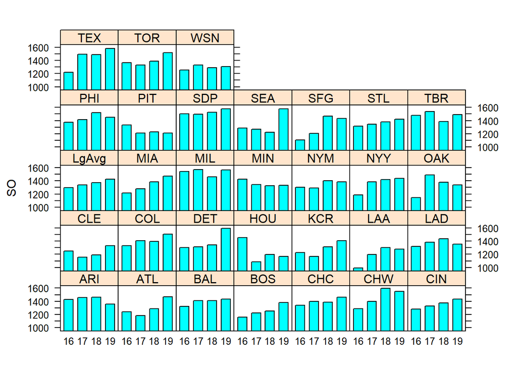

```r
barchart(SO ~ shYear | Tm, baseball)
```

While not as clear cut as home runs were, it does appear that many teams struck out more in 2019 than they did in any other year. However, these graphs also show that strikeouts seem to be increasing year by year, and it is possible that 2019 is only continuing the trend. Lets check this by looking at a linear model of strikeouts explained by year and home runs

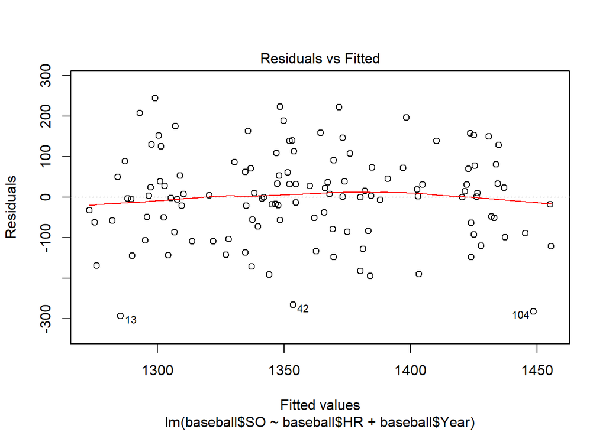

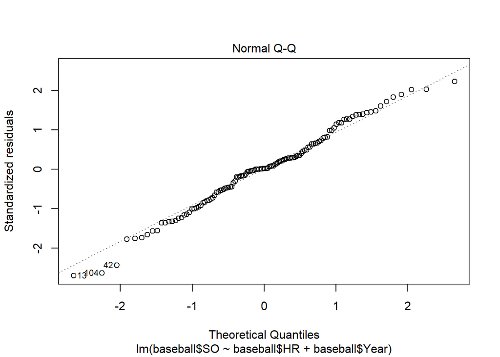

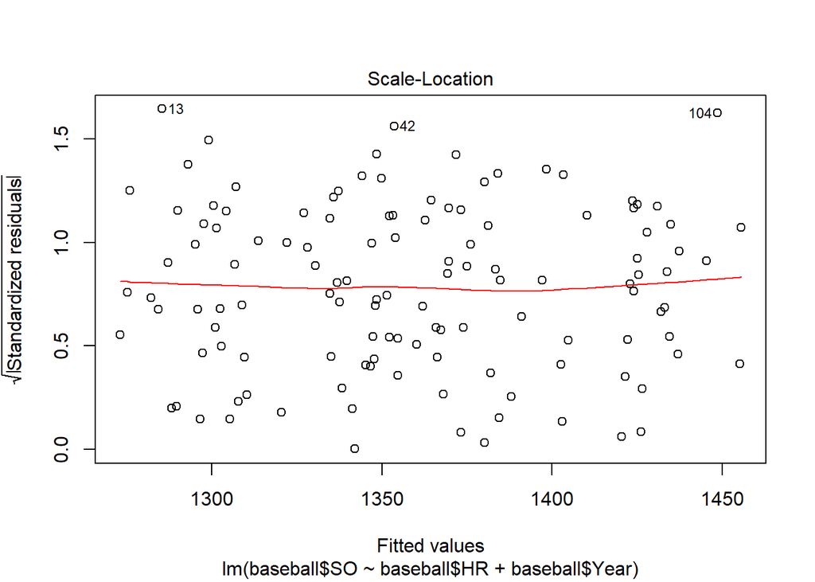

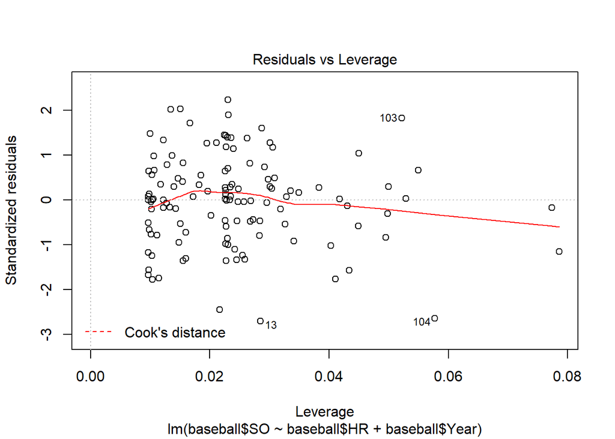

```r
baseball[[21]] <- as.numeric(baseball[[21]])
SOModel <- lm(baseball$SO ~ baseball$HR + baseball$Year, data = baseball)
plot(SOModel)
```

```r
summary(SOModel)
```

```
##
## Call:
## lm(formula = baseball$SO ~ baseball$HR + baseball$Year, data = baseball)
##
## Residuals:
##      Min       1Q   Median       3Q      Max
## -294.381  -66.244    2.179   70.297  243.840
##
## Coefficients:
##                Estimate Std. Error t value Pr(>|t|)
## (Intercept)   1190.3302    55.7807  21.339  < 2e-16 ***
## baseball$HR      0.3626     0.2856   1.269    0.207
## baseball$Year   38.4882     9.3090   4.135 6.59e-05 ***
## ---
## Signif. codes:  0 '***' 0.001 '**' 0.01 '*' 0.05 '.' 0.1 ' ' 1
##
## Residual standard error: 110.4 on 121 degrees of freedom
## Multiple R-squared:  0.1663, Adjusted R-squared:  0.1526
## F-statistic: 12.07 on 2 and 121 DF,  p-value: 1.66e-05
```

```r
anova(SOModel)
```

```
## Analysis of Variance Table
##
## Response: baseball$SO
##                Df  Sum Sq Mean Sq F value    Pr(>F)
## baseball$HR     1   85882   85882  7.0475  0.009005 **
## baseball$Year   1  208312  208312 17.0943 6.592e-05 ***
## Residuals     121 1474518   12186
## ---
## Signif. codes:  0 '***' 0.001 '**' 0.01 '*' 0.05 '.' 0.1 ' ' 1
```

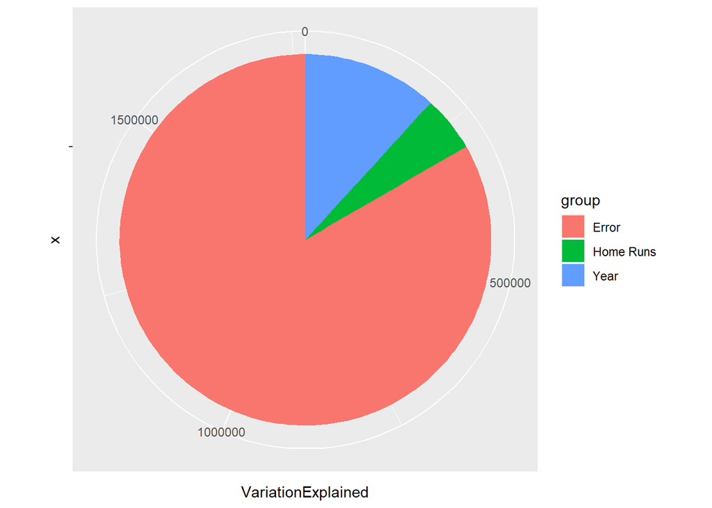

```r
baseball[[21]] <- as.factor(baseball[[21]])
SOchart <-data.frame(
  group = c("Home Runs","Year","Error"),
  value = c(85882,208312,1474518)
)
SOchart$VariationExplained <- SOchart$value
ggplot(SOchart, aes(x="", y=VariationExplained, fill=group))+
geom_bar(width = 1, stat = "identity") + coord_polar("y", start=0)
```

First we need to check our assumptions to see if our linear model is appropriate. Since the relationship appears linear, The variance of the residuals seems even, the QQ normal plot seems linear, and the observations are independent, the assumptions are met and we can continue with our linear model

The linear model using year and home runs to predict strikeouts is

Strikeouts = 1190.33 + 0.3626(HR) + 38.4882(year). The total amount of variation explained in home runs is about 16.6%, with Home runs explaining 5% and year explaining about 12%. The biggest takeaway here seems to be that home runs do not seem to have much of an effect on the amount of strikeouts, meaning that changing the ball did increase home runs but probably didn’t affect strikeouts.

Conclusion